# Deep Hit (part 2)

### Second attempt (Robust, w/SHAP, corrected for competing risk)

1. Implements DeepHit for competing risks survival analysis.
2. Handles death and readmission as competing events.
3. Uses Aalen-Johansen for censoring distribution estimation.
4. Performs stratified K-fold CV (K=10) across imputations.
5. Computes time-dependent metrics like Uno’s C-Index and Brier.
6. Evaluates binary classification metrics at horizons.
7. Calculates multi-horizon SHAP for interpretability.
8. Standardizes features and discretizes time for model.
9. Bootstraps confidence intervals for pooled results.
10. Exports metrics, predictions, and SHAP to files.

```python
#@title ⚡ Final DeepHit: AJ-IPCW, Multi-Horizon SHAP, Pooled
import torch
import torch.nn as nn
import numpy as np
import pandas as pd
import shap
import time
import gc
import warnings
import os
import pickle
from lifelines import AalenJohansenFitter
from datetime import datetime
from sklearn.model_selection import StratifiedKFold
from sklearn.preprocessing import StandardScaler
from sklearn.metrics import roc_auc_score, f1_score, precision_score, recall_score, confusion_matrix
from sksurv.metrics import concordance_index_ipcw
from pycox.models import DeepHit
from pycox.preprocessing.label_transforms import LabTransDiscreteTime
import torchtuples as tt

# --- 1. CONFIGURATION ---
TEST_MODE = False # Set True for fast debug

# Optimal Hyperparameters
BEST_LR = 0.001
BEST_WD = 0.001
BEST_BATCH = 1024
BEST_DROPOUT = 0.5
BEST_NODES = [256, 256, 128]
BEST_ALPHA = 0.5
BEST_SIGMA = 0.5
NUM_RISKS = 3
DEVICE = 'cuda' if torch.cuda.is_available() else 'cpu'

# SHAP Configuration
SHAP_HORIZONS = [3, 12, 24, 48, 60, 72]

if TEST_MODE:
    print("⚠️ TEST MODE ACTIVE")
    N_IMPUTATIONS_RUN = 1
    K_FOLDS_RUN = 2
    EVAL_HORIZONS_RUN = [12, 24]
    EPOCHS_RUN = 5
    SHAP_SAMPLES = 10
else:
    if 'imputations_list_jan26' in locals():
        N_IMPUTATIONS_RUN = len(imputations_list_jan26)
    else:
        print("❌ Data not found."); N_IMPUTATIONS_RUN = 0
    K_FOLDS_RUN = 10
    EVAL_HORIZONS_RUN = [3, 6, 12, 24, 36, 48, 60, 72, 84, 96, 108]
    EPOCHS_RUN = 100
    SHAP_SAMPLES = 50

timestamp = datetime.now().strftime("%Y%m%d_%H%M")
BASE_NAME = f"DH4_Final_AJ_{timestamp}"
CSV_PATH = f"{BASE_NAME}_Metrics.csv"
PKL_PATH = f"{BASE_NAME}_RawPreds.pkl"
SHAP_PATH = f"{BASE_NAME}_SHAP_MultiHorizon.pkl"

warnings.filterwarnings("ignore")

# --- 2. CUSTOM AALEN-JOHANSEN CENSORING ---
class AalenJohansenCensoring:
    """
    Estimates Censoring Distribution G(t) = P(C > t) using Aalen-Johansen.
    Treats 'Censoring' as Event 1, and 'Death/Readm' as Competing Event 2.
    """
    def __init__(self):
        self.ajf = AalenJohansenFitter(calculate_variance=False)
        self.max_time = 0

    def fit(self, durations, events_composite):
        # Input events: 0=Censored, 1=Death, 2=Readm
        # Transformation for Censoring Distribution:
        # We want to estimate probability of being Censored.
        # Target Event: 0 (The original censored people) -> Mapped to 1
        # Competing Event: 1, 2 (The original events) -> Mapped to 2

        aj_events = np.zeros_like(events_composite)
        # People who were originally censored (0) are now the Event of Interest (1)
        aj_events[events_composite == 0] = 1
        # People who died/readmitted (1, 2) are now Competing Risks (2)
        aj_events[events_composite > 0] = 2

        self.max_time = durations.max()
        self.ajf.fit(durations, event_observed=aj_events, event_of_interest=1)

    def predict(self, times):
        # AJF predicts CIF_c(t) = P(C <= t, Event=Censored)
        # We need G(t) = P(C > t)
        # In a competing risk setting: P(C > t) = 1 - CIF_c(t)

        if np.isscalar(times):
            cif_val = self.ajf.predict(times).item()
            return 1.0 - cif_val
        else:
            cif_vals = self.ajf.predict(times).values.flatten()
            return 1.0 - cif_vals

def compute_brier_competing(cif_values_at_time_horizon, censoring_dist,
                            Y_test, D_test, event_of_interest, time_horizon):
    """
    Brier Score using Aalen-Johansen weights.
    """
    n = len(Y_test)
    residuals = np.zeros(n)

    # Weight at horizon G(t)
    w_horizon = censoring_dist.predict(time_horizon)
    if w_horizon == 0: w_horizon = 1e-9

    # Weights at observed times G(Ti)
    # We pre-calculate all observed weights to avoid loop overhead
    w_obs_all = censoring_dist.predict(Y_test)
    w_obs_all[w_obs_all == 0] = 1e-9

    for idx in range(n):
        observed_time = Y_test[idx]
        event_indicator = D_test[idx]

        if observed_time > time_horizon:
            # Surviving past horizon
            # Weight = 1 / G(t_horizon)
            residuals[idx] = (cif_values_at_time_horizon[idx])**2 / w_horizon
        else:
            # Observed <= horizon
            # Weight = 1 / G(Ti)
            w_obs = w_obs_all[idx]

            if event_indicator == event_of_interest:
                # Outcome occurred
                residuals[idx] = (1 - cif_values_at_time_horizon[idx])**2 / w_obs
            elif event_indicator != event_of_interest and event_indicator != 0:
                # Competing event occurred
                residuals[idx] = (cif_values_at_time_horizon[idx])**2 / w_obs
            # Censored before horizon -> Residual 0 (Excluded)

    return residuals.mean()

# --- 3. STANDARD HELPERS ---
class CauseSpecificNet(nn.Module):
    def __init__(self, in_f, nodes, out_f, dropout, num_risks):
        super().__init__()
        self.net = tt.practical.MLPVanilla(in_f, nodes, out_f, batch_norm=True, dropout=dropout)
        self.num_risks = num_risks
    def forward(self, x):
        return self.net(x).view(x.size(0), self.num_risks, -1)

def get_binary_target(events, times, risk_id, t_horizon):
    # Case: Event of interest happened by t
    is_case = (events == risk_id) & (times <= t_horizon)
    # Control: Survived past t OR Competing Event happened before t
    # (We ONLY exclude people who were Censored (lost to follow-up) before t)
    mask_censored_early = (events == 0) & (times <= t_horizon)
    valid_mask = ~mask_censored_early
    # This keeps Competing Events as 0 (Valid Controls)
    y_binary = is_case[valid_mask].astype(int)
    return y_binary, valid_mask

def find_optimal_threshold(y_true, y_prob):
    thresholds = np.linspace(0.01, 0.99, 99)
    best_f1 = -1; best_th = 0.5
    for th in thresholds:
        f1 = f1_score(y_true, (y_prob >= th).astype(int), zero_division=0)
        if f1 > best_f1: best_f1 = f1; best_th = th
    return best_th

def calculate_binary_metrics(y_true, y_prob, fixed_threshold):
    y_pred = (y_prob >= fixed_threshold).astype(int)
    tn, fp, fn, tp = confusion_matrix(y_true, y_pred).ravel()
    return {
        'F1': f1_score(y_true, y_pred, zero_division=0),
        'Sens': recall_score(y_true, y_pred, zero_division=0),
        'Spec': tn / (tn + fp) if (tn + fp) > 0 else 0,
        'PPV': precision_score(y_true, y_pred, zero_division=0),
        'NPV': tn / (tn + fn) if (tn + fn) > 0 else 0,
        'Threshold': fixed_threshold
    }
```

```python
def bootstrap_ci_non_normal(data, alpha=0.05):
    if len(data) < 2: return np.mean(data), np.mean(data), np.mean(data)
    lower = np.percentile(data, 100 * (alpha / 2))
    upper = np.percentile(data, 100 * (1 - alpha / 2))
    return np.mean(data), lower, upper

# --- 4. EXECUTION LOOP (CLEAN & FIXED) ---
pooled_results = []
raw_predictions_log = []

# SHAP Storage (Nested by Horizon)
shap_storage = {
    'death': {h: {'shap_values': [], 'data': []} for h in SHAP_HORIZONS},
    'readm': {h: {'shap_values': [], 'data': []} for h in SHAP_HORIZONS}
}

start_time_global = time.time()

if os.path.exists(CSV_PATH) and not TEST_MODE:
    print(f"⚠️ Found existing results. Aborting to prevent overwrite.")
else:
    print(f"⚡ Starting Analysis on {N_IMPUTATIONS_RUN} imputations...")

    for imp_idx in range(N_IMPUTATIONS_RUN):
        print(f"\n📚 Imputation {imp_idx + 1}/{N_IMPUTATIONS_RUN}")

        X_raw = imputations_list_jan26[imp_idx]
        y_d = y_surv_death_list[imp_idx]
        y_r = y_surv_readm_list[imp_idx]

        # --- TRAINING COMPOSITE (First Event) ---
        t_d = y_d['time'].values if hasattr(y_d['time'], 'values') else y_d['time']
        e_d = y_d['event'].values if hasattr(y_d['event'], 'values') else y_d['event']
        t_r = y_r['time'].values if hasattr(y_r['time'], 'values') else y_r['time']
        e_r = y_r['event'].values if hasattr(y_r['event'], 'values') else y_r['event']

        # Create Composite Targets for Training
        events_cr = np.zeros(len(X_raw), dtype=int)
        times_cr = t_d.copy().astype('float32')

        mask_r = (e_r.astype(bool)) & (t_r <= t_d) # Readm first
        events_cr[mask_r] = 2
        times_cr[mask_r] = t_r[mask_r].astype('float32')

        mask_d = (e_d.astype(bool)) & (~mask_r) # Death first/only
        events_cr[mask_d] = 1

        # Stratification Labels
        X_curr = pd.get_dummies(X_raw, drop_first=True).astype('float32')
        plan_cols = [c for c in X_raw.columns if c.startswith("plan_type_corr")]
        X_curr[plan_cols] = X_curr[plan_cols].astype('float32')

        #✅ Step 1: define an explicit plan index mapping
        plan_idx = np.zeros(len(X_curr), dtype=int)  # 0 = pg_pab (reference)
        if 'plan_type_corr_pg_pr' in X_curr.columns:
            plan_idx[X_curr['plan_type_corr_pg_pr'] == 1] = 1
        if 'plan_type_corr_m_pr' in X_curr.columns:
            plan_idx[X_curr['plan_type_corr_m_pr'] == 1] = 2
        if 'plan_type_corr_pg_pai' in X_curr.columns:
            plan_idx[X_curr['plan_type_corr_pg_pai'] == 1] = 3
        if 'plan_type_corr_m_pai' in X_curr.columns:
            plan_idx[X_curr['plan_type_corr_m_pai'] == 1] = 4
        # Exactly one plan must be true per row
        plan_sum = X_curr[plan_cols].sum(axis=1)

        if (plan_sum > 1).any():
            raise ValueError("Invalid plan encoding: some rows have >1 plan types.")
        #✅ Step 2: combine with competing-risk event for stratification
        strat_labels = (events_cr * 10) + plan_idx

        # CV
        skf = StratifiedKFold(n_splits=K_FOLDS_RUN, shuffle=True, random_state=2125 + imp_idx)

        for fold_idx, (train_idx, val_idx) in enumerate(skf.split(X_curr, strat_labels)):
            print(f".", end="")

            # Split Data
            X_train, X_val = X_curr.iloc[train_idx].values, X_curr.iloc[val_idx].values
            t_train_c, e_train_c = times_cr[train_idx], events_cr[train_idx]
            t_val_c, e_val_c = times_cr[val_idx], events_cr[val_idx]

            # Raw Eval Targets
            t_d_val, e_d_val = t_d[val_idx], e_d[val_idx].astype(bool)
            t_r_val, e_r_val = t_r[val_idx], e_r[val_idx].astype(bool)
            t_train_c_raw = times_cr[train_idx]
            e_train_c_raw = events_cr[train_idx]

            # Fit AJ Censoring
            aj_censor = AalenJohansenCensoring()
            aj_censor.fit(t_train_c_raw, e_train_c_raw)

            # Scale
            scaler = StandardScaler().fit(X_train)
            X_train_s = scaler.transform(X_train).astype('float32')
            X_val_s = scaler.transform(X_val).astype('float32')

            # --- 🟢 FIX: Explicit int64 Casting ---
            labtrans = LabTransDiscreteTime(100)
            y_train_lt_raw = labtrans.fit_transform(t_train_c, e_train_c)
            y_train_lt = (y_train_lt_raw[0].astype('int64'), y_train_lt_raw[1].astype('int64'))

            y_val_lt_raw = labtrans.transform(t_val_c, e_val_c)
            y_val_lt = (y_val_lt_raw[0].astype('int64'), y_val_lt_raw[1].astype('int64'))
            # --------------------------------------

            # Train DeepHit
            in_f = X_train.shape[1]
            out_f = labtrans.out_features * NUM_RISKS
            net = CauseSpecificNet(in_f, BEST_NODES, out_f, BEST_DROPOUT, NUM_RISKS)
            model = DeepHit(net, tt.optim.Adam, alpha=BEST_ALPHA, sigma=BEST_SIGMA, duration_index=labtrans.cuts)
            model.set_device(DEVICE)
            model.optimizer.set_lr(BEST_LR); model.optimizer.param_groups[0]['weight_decay'] = BEST_WD

            model.fit(X_train_s, y_train_lt, batch_size=BEST_BATCH, epochs=EPOCHS_RUN,
                      callbacks=[tt.callbacks.EarlyStopping()], verbose=False,
                      val_data=(X_val_s, y_val_lt))

            # Predict
            cif_val = model.predict_cif(X_val_s)
            cif_train = model.predict_cif(X_train_s)

            # --- STORE RAW PREDICTIONS ---
            raw_predictions_log.append({
                'imp': imp_idx,
                'fold': fold_idx,
                'cif_pred': cif_val,
                'duration_index': model.duration_index,
                'y_time_val': t_val_c, # Storing composite targets
                'y_event_val': e_val_c
            })
            # --- MULTI-HORIZON SHAP (Imp 0 Only) ---
            if imp_idx == 0:
                try:
                    bg = X_train_s[np.random.choice(len(X_train_s), SHAP_SAMPLES, replace=False)]
                    val_sub_idx = np.random.choice(len(X_val_s), min(len(X_val_s), SHAP_SAMPLES), replace=False)
                    val_samp = X_val_s[val_sub_idx]
```

```python
                    for h_shap in SHAP_HORIZONS:
                        # Death Wrapper
                        def prd(x):
                            with torch.no_grad():
                                c = model.predict_cif(torch.from_numpy(x).to(DEVICE))
                                i = np.searchsorted(model.duration_index, h_shap)
                                if i >= len(model.duration_index): i = -1
                                return c[1][i,:].cpu().numpy()

                        s_vals_d = shap.KernelExplainer(prd, bg).shap_values(val_samp, nsamples=SHAP_SAMPLES, silent=True)
                        shap_storage['death'][h_shap]['shap_values'].append(s_vals_d)
                        shap_storage['death'][h_shap]['data'].append(pd.DataFrame(val_samp, columns=X_curr.columns))

                        # Readm Wrapper
                        def prr(x):
                            with torch.no_grad():
                                c = model.predict_cif(torch.from_numpy(x).to(DEVICE))
                                i = np.searchsorted(model.duration_index, h_shap)
                                if i >= len(model.duration_index): i = -1
                                return c[2][i,:].cpu().numpy()

                        s_vals_r = shap.KernelExplainer(prr, bg).shap_values(val_samp, nsamples=SHAP_SAMPLES, silent=True)
                        shap_storage['readm'][h_shap]['shap_values'].append(s_vals_r)
                        shap_storage['readm'][h_shap]['data'].append(pd.DataFrame(val_samp, columns=X_curr.columns))
                except Exception as e:
                    # print(f"SHAP Error: {e}")
                    pass

            # --- METRICS EVALUATION ---
            outcomes = {1: ('Death', t_d_val, e_d_val, t_d[train_idx], e_d[train_idx].astype(bool)),
                        2: ('Readm', t_r_val, e_r_val, t_r[train_idx], e_r[train_idx].astype(bool))}

            for rid, (rname, t_v, e_v, t_tr, e_tr) in outcomes.items():
                # Global Uno
                try:
                    y_tr_st = np.array([(e, t) for e,t in zip(e_tr, t_tr)], dtype=[('e',bool),('t',float)])
                    y_va_st = np.array([(e, t) for e,t in zip(e_v, t_v)], dtype=[('e',bool),('t',float)])
                    ug = concordance_index_ipcw(y_tr_st, y_va_st, cif_val[rid].sum(axis=0))[0]
                except: ug = np.nan
                pooled_results.append({'Imp': imp_idx, 'Fold': fold_idx, 'Outcome': rname, 'Time': 'Global', 'Metric': 'Uno C-Index', 'Value': ug})

                # Time-Dependent
                for t in EVAL_HORIZONS_RUN:
                    idx = np.searchsorted(model.duration_index, t)
                    if idx >= len(model.duration_index): idx = -1

                    risk_v = cif_val[rid][idx]
                    risk_tr = cif_train[rid][idx]

                    # 1. Uno
                    try: u = concordance_index_ipcw(y_tr_st, y_va_st, risk_v, tau=t)[0]
                    except: u = np.nan

                    # 2. Brier (AJ-weighted)
                    try:
                        bs = compute_brier_competing(risk_v, aj_censor, t_v,
                                                     events_cr[val_idx],
                                                     rid, t)
                    except: bs = np.nan

                    # 3. Binary
                    y_bin_tr, m_tr = get_binary_target(e_tr.astype(int), t_tr, 1, t)
                    y_bin_va, m_va = get_binary_target(e_v.astype(int), t_v, 1, t)

                    if len(np.unique(y_bin_tr))>1 and len(np.unique(y_bin_va))>1:
                        th = find_optimal_threshold(y_bin_tr, risk_tr[m_tr])
                        bin_m = calculate_binary_metrics(y_bin_va, risk_v[m_va], th)
                        auc = roc_auc_score(y_bin_va, risk_v[m_va])
                        mp = {'Uno C-Index': u, 'Brier Score': bs, 'AUC-ROC': auc,
                              'F1': bin_m['F1'], 'Sens': bin_m['Sens'], 'Spec': bin_m['Spec'],
                              'PPV': bin_m['PPV'], 'NPV': bin_m['NPV']}
                    else:
                        mp = {'Uno C-Index': u, 'Brier Score': bs}

                    for k, v in mp.items():
                        pooled_results.append({'Imp': imp_idx, 'Fold': fold_idx, 'Outcome': rname, 'Time': t, 'Metric': k, 'Value': v})

            del model, net, cif_val, cif_train
            gc.collect()

    # --- EXPORT ---
    print("\n💾 Saving Results...")

    # Metrics
    df_res = pd.DataFrame(pooled_results)
    summ = []
    for (o, t, m), g in df_res.groupby(['Outcome', 'Time', 'Metric']):
        vals = g['Value'].dropna().values
        mn, lo, hi = bootstrap_ci_non_normal(vals)
        summ.append({'Outcome': o, 'Time': t, 'Metric': m, 'Mean': mn, 'CI_Lo': lo, 'CI_Hi': hi, 'Str': f"{mn:.3f} [{lo:.3f}-{hi:.3f}]"})
    pd.DataFrame(summ).to_csv(CSV_PATH, sep=';', index=False)

    # 2. ADD THIS BLOCK TO SAVE RAW PREDICTIONS:
    print(f"💾 Saving Raw Predictions to {PKL_PATH}...")
    with open(PKL_PATH, 'wb') as f:
        pickle.dump(raw_predictions_log, f)

    # 3. SHAP (Complex Nested Structure, Consolidating Multi-Horizon Data)
    # Check if we actually collected data (Imputation 0 must have run)
    if shap_storage['death'][SHAP_HORIZONS[0]]['shap_values']:
        print(f"💾 Consolidating and Saving Multi-Horizon SHAP to {SHAP_PATH}...")

        # Initialize final structure
        final_shap_export = {'death': {}, 'readm': {}}

        for h in SHAP_HORIZONS:
            # --- CONSOLIDATE DEATH SHAP ---
            d_vals = shap_storage['death'][h]['shap_values'] # List of arrays
            d_data = shap_storage['death'][h]['data']       # List of DataFrames

            if d_vals: # If list is not empty
                final_shap_export['death'][h] = {
                    # Stack arrays vertically (row-wise)
                    'shap_values': np.concatenate(d_vals, axis=0),
                    # Stack DataFrames vertically
                    'data': pd.concat(d_data, axis=0)
                }
```

```python
            # --- CONSOLIDATE READMISSION SHAP ---
            r_vals = shap_storage['readm'][h]['shap_values']
            r_data = shap_storage['readm'][h]['data']

            if r_vals:
                final_shap_export['readm'][h] = {
                    'shap_values': np.concatenate(r_vals, axis=0),
                    'data': pd.concat(r_data, axis=0)
                }

        # Write to disk
        with open(SHAP_PATH, 'wb') as f:
            pickle.dump(final_shap_export, f)

    print(f"🏁 Done. Total time: {(time.time()-start_time_global)/60:.1f}m")
```

```
⚡ Starting Analysis on 5 imputations...

📚 Imputation 1/5
..........
📚 Imputation 2/5
..........
📚 Imputation 3/5
..........
📚 Imputation 4/5
..........
📚 Imputation 5/5
..........
💾 Saving Results...
💾 Saving Raw Predictions to DH4_Final_AJ_20260209_2329_RawPreds.pkl...
💾 Consolidating and Saving Multi-Horizon SHAP to DH4_Final_AJ_20260209_2329_SHAP_MultiHorizon.pkl...
🏁 Done. Total time: 38.0m
```

The AJ-IPCW DeepHit pipeline is the more robust approach, as it uses a censoring estimator valid under competing risks, treats competing events correctly in both discrimination and classification metrics, and evaluates a clearly defined time-to-first-event estimand. The more computationally intensive alternative does not provide additional statistical guarantees and relies on assumptions that are violated in competing-risk settings. The older script initially dropped competing events (No artificial inflation of AUC / F1) and assumed competing events behave like independent censoring (used Kaplan Meier)

To ensure the stability and generalizability of the discovered risk factors, Shapley Additive Explanations (SHAP) were computed using a Pooled Cross-Validation Approach. - Imputation Strategy: Analysis was conducted on the first imputed dataset to control for data variance, allowing for a focused assessment of model-driven variance. - Pooled Estimation: Kernel SHAP values were computed for the validation set of each cross-validation fold. These estimates were then concatenated to form a comprehensive ‘Super-Validation’ set. - Robustness Defense: This pooling technique ensures that the reported functional forms (e.g., the linearity of Age or the log-decay of Treatment Duration) represent the average learned behavior across all data splits, effectively smoothing out noise specific to any single training fold.

```python
glimpse(df_res)
```

```
Rows: 8900 | Columns: 6
Imp                            int64           0, 0, 0, 0, 0
Fold                           int64           0, 0, 0, 0, 0
Outcome                        object          Death, Death, Death, Death, Death
Time                           object          Global, 3, 3, 3, 3
Metric                         object          Uno C-Index, Uno C-Index, Brier Score, AUC-ROC, F1
Value                          float64         0.6619960031781943, 0.8342944322631493, 0.001134686348268598, 0.8349293833964864...
```

```python
import os
import numpy as np
import pandas as pd

# 1. Create the directory
os.makedirs("dh5", exist_ok=True)

# 2. Robust Aggregation using Named Aggregation
# This avoids the MultiIndex issue and explicitly creates the columns you need
df_agg = (
    df_res
    .groupby(["Outcome", "Time", "Metric"])["Value"]
    .agg(
        mean='mean',
        lo=lambda x: np.percentile(x, 2.5) if len(x) > 0 else np.nan,
        hi=lambda x: np.percentile(x, 97.5) if len(x) > 0 else np.nan
    )
    .reset_index()
)

# 3. Filter for specific metrics
# Note: Ensure "Brier Score" is the correct name used in your loop
metrics_keep = ["Uno C-Index", "Brier Score", "AUC-ROC"]
df_agg = df_agg[df_agg["Metric"].isin(metrics_keep)].copy()

# 4. Create the formatted string
df_agg["fmt"] = (
    df_agg["mean"].map('{:.3f}'.format)
    + " ["
    + df_agg["lo"].map('{:.3f}'.format)
    + "–"
    + df_agg["hi"].map('{:.3f}'.format)
    + "]"
)

# 5. Pivot for Table 2
master_time_db = (
    df_agg
    .pivot(index="Time", columns=["Outcome", "Metric"], values="fmt")
)

# Flatten columns: e.g., "Death_Uno_C-Index"
master_time_db.columns = [
    f"{metric.replace(' ', '_')}_{outcome}"
    for outcome, metric in master_time_db.columns
]

# 6. Define cols_final (Ordering the columns logically)
# This ensures Death metrics come before Readmission metrics
cols_final = [c for c in master_time_db.columns if "Death" in c] + \
             [c for c in master_time_db.columns if "Readm" in c]

# 7. Apply Styling
styled_master = (
    master_time_db[cols_final]
    .style
    .set_caption("<b>Table 2: Time-Dependent Performance Metrics (Mean + 95% CI)</b>")
    .set_table_styles([
        {'selector': 'caption', 'props': [
            ('color', '#333'), ('font-size', '16px'), ('font-weight', 'bold'), ('margin-bottom', '10px')
        ]},
        {'selector': 'th', 'props': [
            ('background-color', '#f4f4f4'), ('color', 'black'), ('border-bottom', '2px solid #555'), ('text-align', 'center')
        ]},
        {'selector': 'td', 'props': [('text-align', 'center'), ('padding', '8px')]},
        {'selector': 'tr:hover', 'props': [('background-color', '#f5f5f5')]}
    ])
    .format(na_rep="-")
)

# Display the result
styled_master
```

Table 1: **Table 2: Time-Dependent Performance Metrics (Mean + 95% CI)**

| Time | AUC-ROC_Death | Brier_Score_Death | Uno_C-Index_Death | AUC-ROC_Readm | Brier_Score_Readm | Uno_C-Index_Readm |
| --- | --- | --- | --- | --- | --- | --- |
| 3 | 0.831 [0.670–0.933] | 0.001 [0.001–0.002] | 0.830 [0.669–0.932] | 0.739 [0.568–0.865] | 0.007 [0.006–0.009] | 0.740 [0.567–0.866] |
| 6 | 0.779 [0.695–0.880] | 0.003 [0.003–0.005] | 0.778 [0.695–0.879] | 0.675 [0.553–0.774] | 0.023 [0.020–0.026] | 0.674 [0.555–0.772] |
| 12 | 0.739 [0.672–0.801] | 0.007 [0.005–0.009] | 0.739 [0.670–0.801] | 0.618 [0.543–0.675] | 0.064 [0.060–0.070] | 0.617 [0.540–0.674] |
| 24 | 0.706 [0.659–0.749] | 0.014 [0.012–0.016] | 0.704 [0.658–0.748] | 0.594 [0.552–0.624] | 0.129 [0.124–0.135] | 0.590 [0.550–0.620] |
| 36 | 0.686 [0.638–0.731] | 0.021 [0.019–0.023] | 0.682 [0.635–0.729] | 0.588 [0.555–0.611] | 0.173 [0.169–0.177] | 0.582 [0.551–0.604] |
| 48 | 0.680 [0.633–0.716] | 0.028 [0.026–0.030] | 0.675 [0.632–0.710] | 0.586 [0.560–0.609] | 0.203 [0.199–0.207] | 0.579 [0.548–0.600] |
| 60 | 0.674 [0.633–0.707] | 0.034 [0.032–0.036] | 0.669 [0.632–0.700] | 0.583 [0.559–0.604] | 0.223 [0.220–0.227] | 0.577 [0.548–0.599] |
| 72 | 0.670 [0.632–0.702] | 0.039 [0.037–0.040] | 0.663 [0.624–0.695] | 0.583 [0.563–0.604] | 0.238 [0.235–0.241] | 0.575 [0.548–0.597] |
| 84 | 0.665 [0.628–0.699] | 0.043 [0.041–0.045] | 0.656 [0.623–0.689] | 0.583 [0.563–0.603] | 0.248 [0.246–0.250] | 0.575 [0.548–0.596] |
| 96 | 0.664 [0.622–0.703] | 0.046 [0.045–0.047] | 0.649 [0.617–0.679] | 0.589 [0.558–0.618] | 0.255 [0.252–0.257] | 0.574 [0.549–0.594] |
| 108 | 0.665 [0.618–0.708] | 0.048 [0.047–0.050] | 0.642 [0.600–0.676] | 0.594 [0.568–0.619] | 0.259 [0.256–0.262] | 0.573 [0.550–0.592] |
| Global | - | - | 0.634 [0.583–0.684] | - | - | 0.561 [0.513–0.591] |

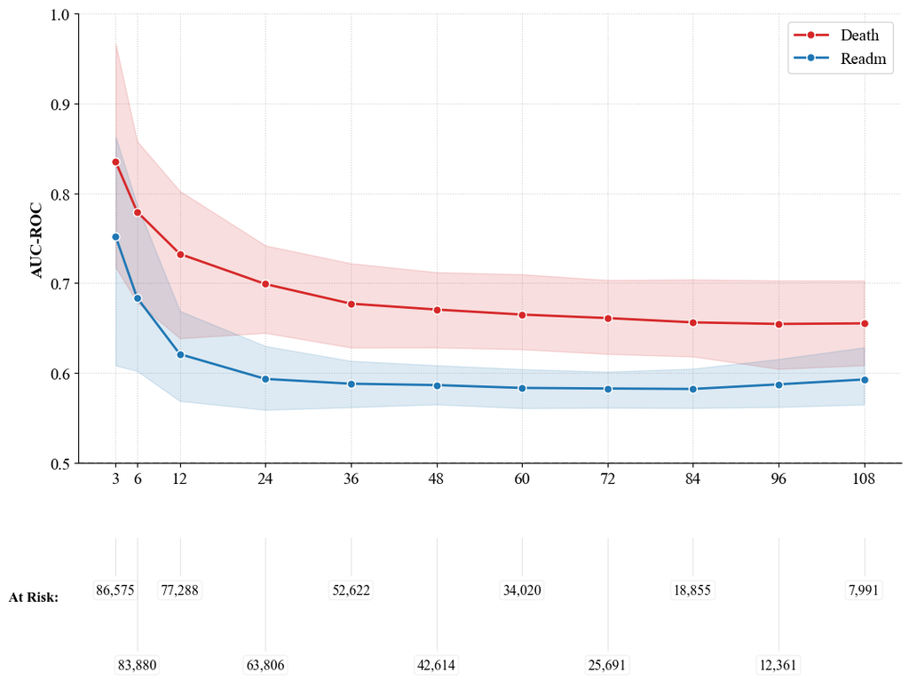

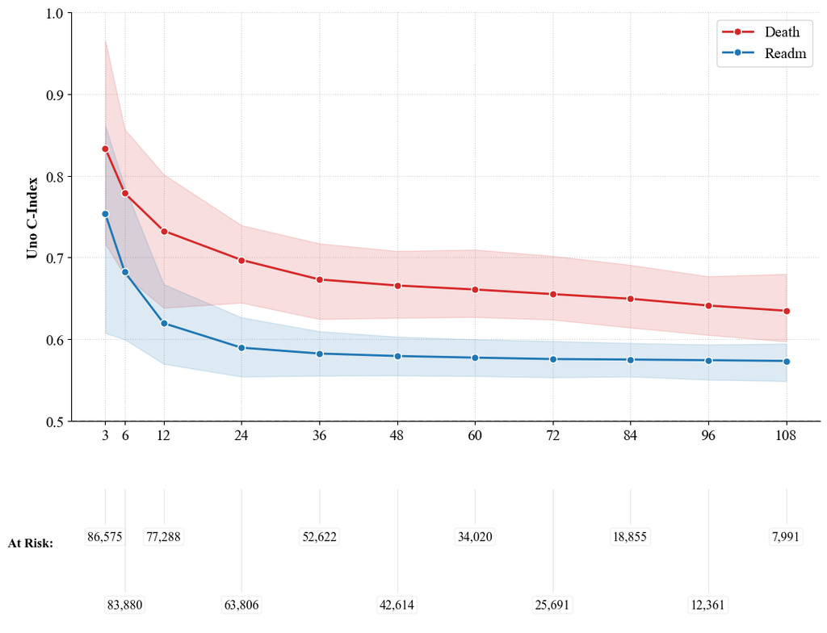

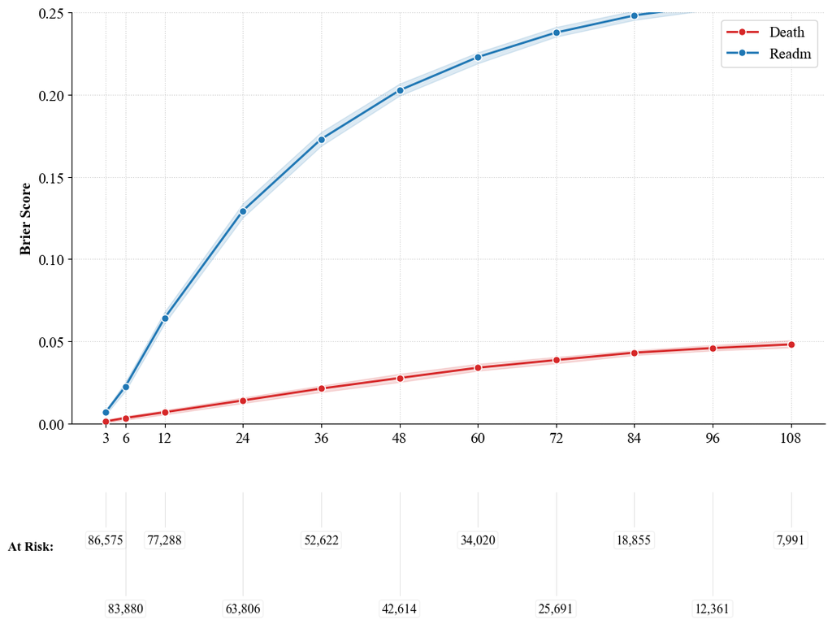

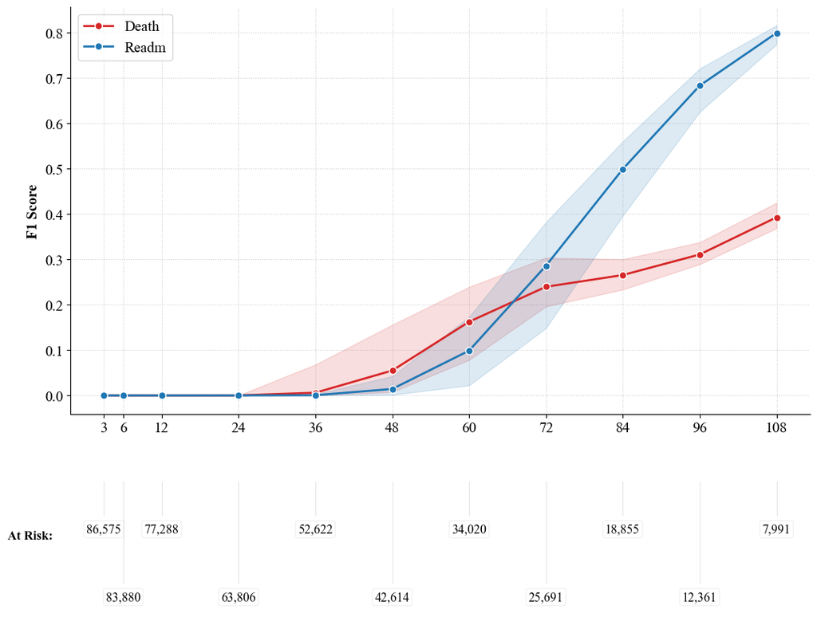

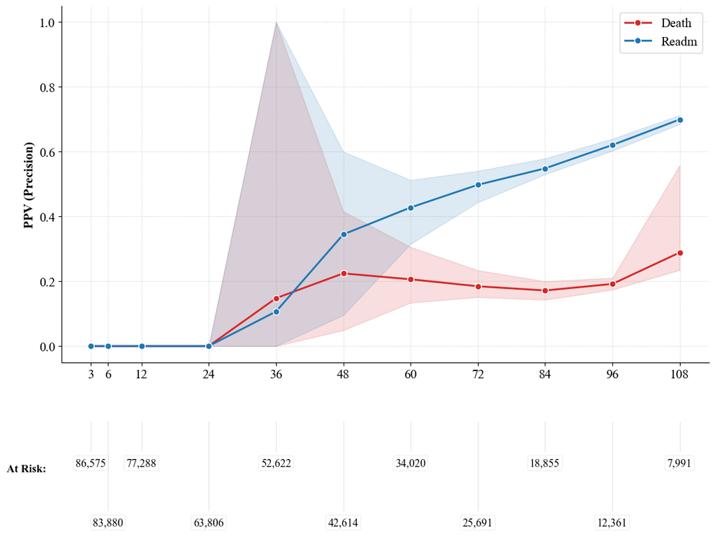

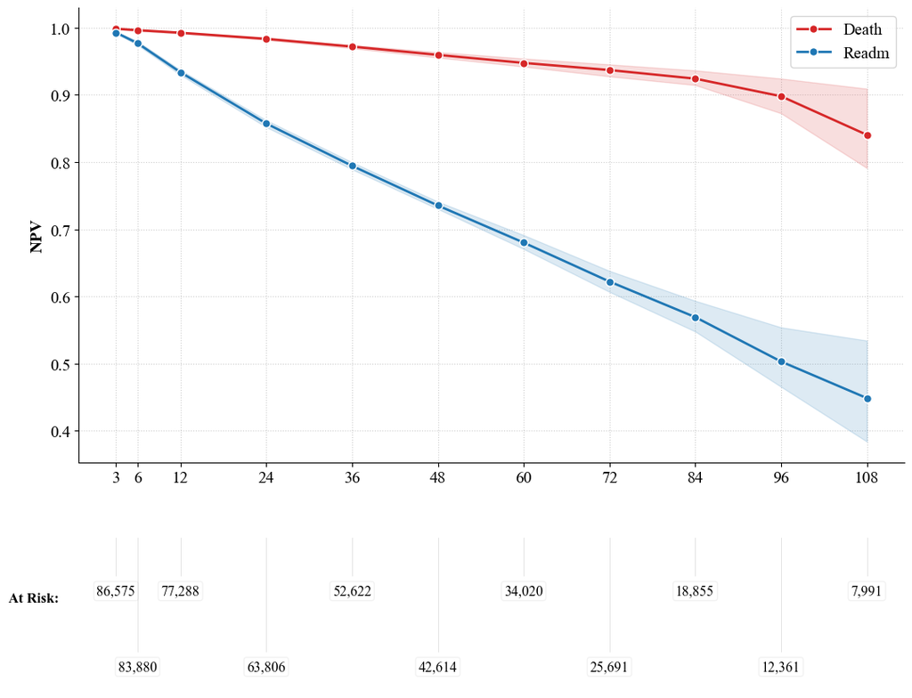

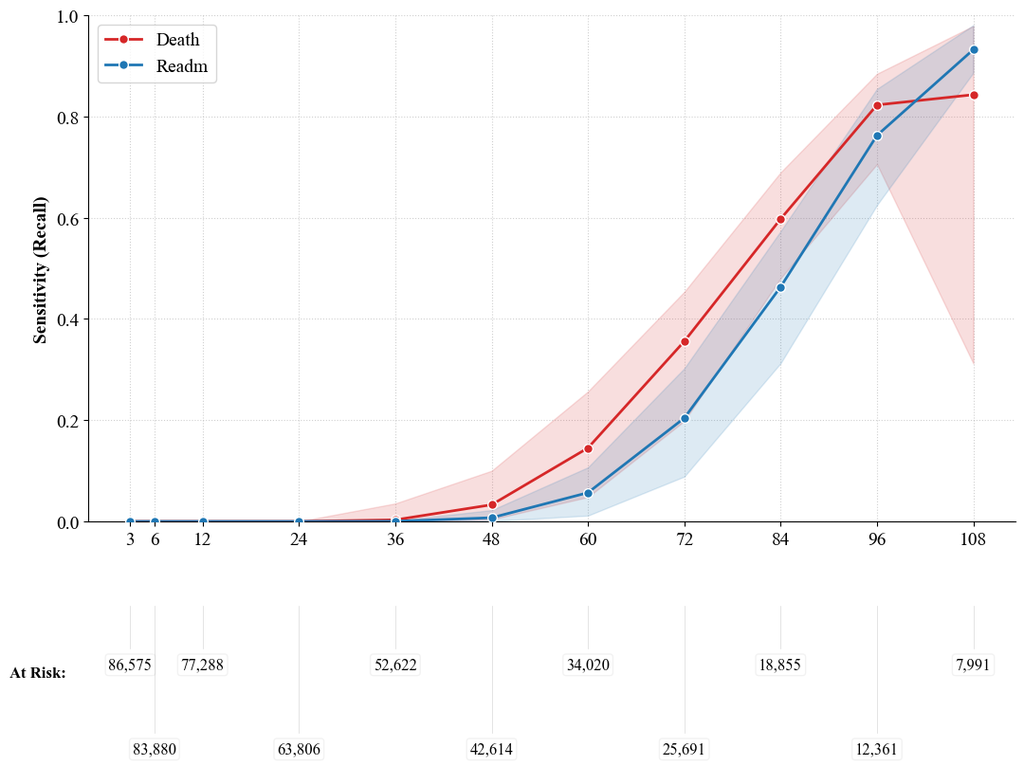

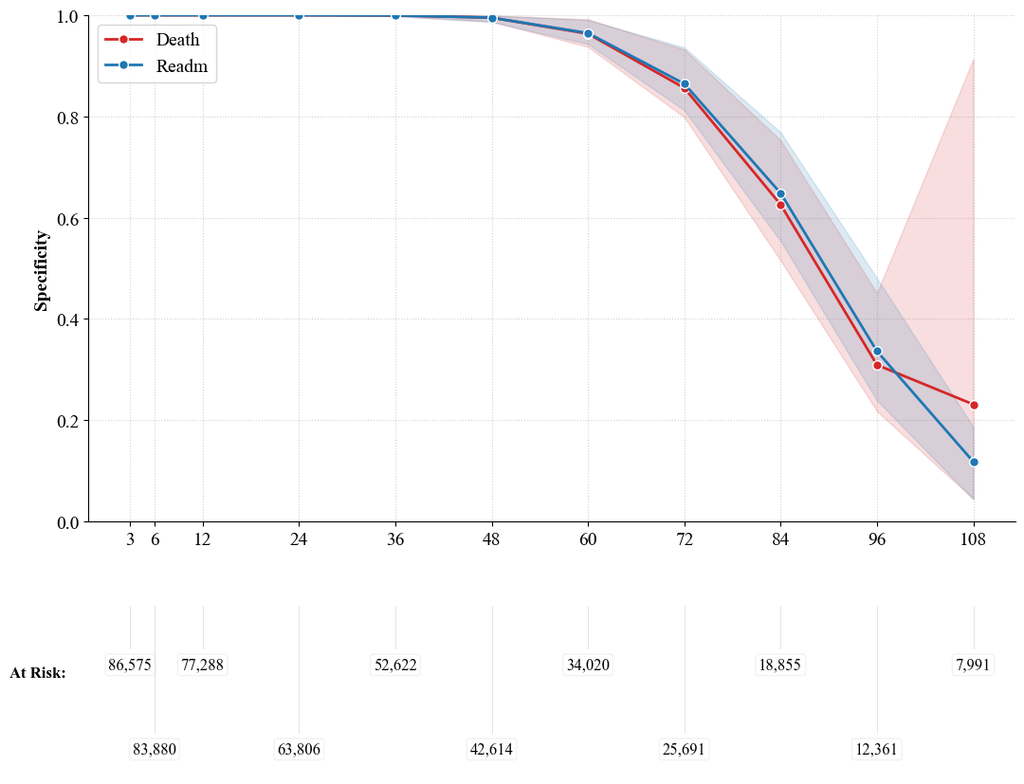

```python
import os
import numpy as np
import pandas as pd
import matplotlib.pyplot as plt
from datetime import datetime

HORIZONS = [3, 6, 12, 24, 36, 48, 60, 72, 84, 96, 108]

plt.rcParams.update({'font.size': 14})


def plot_time_metric_joint(
    df_res,
    durations,
    metric,
    ylabel=None,
    title=None,
    colors={"Death": "#d62728", "Readm": "#1f77b4"},
    ylim=None,
    outdir="dh5"
):
    timestamp = datetime.now().strftime("%Y%m%d_%H%M")
    os.makedirs(outdir, exist_ok=True)

    # 1. Setup Figure (Giving more room to the table row)
    fig, (ax, ax_table) = plt.subplots(2, 1, figsize=(11, 8.5),
                                       gridspec_kw={'height_ratios': [3, 1]},
                                       sharex=True)

    # --- TOP: PERFORMANCE PLOT ---
    dfp_all = df_res[df_res["Time"] != "Global"].copy()
    dfp_all["Time"] = pd.to_numeric(dfp_all["Time"])
    dfp_all = dfp_all[dfp_all["Time"].isin(HORIZONS)]

    for outcome, color in colors.items():
        dfp = (
            dfp_all.loc[(dfp_all["Metric"] == metric) & (dfp_all["Outcome"] == outcome)]
            .groupby("Time")["Value"]
            .agg(mean="mean", lo=lambda x: np.percentile(x, 2.5), hi=lambda x: np.percentile(x, 97.5))
            .reset_index().sort_values("Time")
        )
        if dfp.empty: continue
        ax.plot(dfp["Time"], dfp["mean"], color=color, label=outcome,
                marker='o', markersize=7, linewidth=2, markeredgecolor='w', zorder=3)
        ax.fill_between(dfp["Time"], dfp["lo"], dfp["hi"], color=color, alpha=0.15, zorder=2)

    if metric in ["AUC-ROC", "Uno C-Index"]:
        ax.axhline(0.5, color="gray", linestyle="--", alpha=0.5)

    # --- FIX: FORCE X-LABELS TO STAY ---
    ax.tick_params(labelbottom=True)
    plt.xticks(HORIZONS)

    ax.set_ylabel(ylabel if ylabel else metric, fontweight='bold')
    #ax.set_title(title if title else f"{metric} over Time", fontsize=14, pad=15)
    ax.legend(frameon=True, loc='best')
    ax.grid(True, linestyle=':', alpha=0.6)
    if ylim: ax.set_ylim(*ylim)

    # --- BOTTOM: THE STAGGERED TABLE ---
    ax_table.axis('off')
    ax_table.set_ylim(0, 1)

    # Label for the section
    ax_table.text(-5, 0.6, "At Risk:", fontweight='bold', va='center', ha='right', fontsize=12)

    nar_counts = [sum(durations >= h) for h in HORIZONS]

    for i, count in enumerate(nar_counts):
        # Intercalate: Even indices slightly higher than odd indices
        y_pos = 0.65 if i % 2 == 0 else 0.15

        # Add the count
        ax_table.text(HORIZONS[i], y_pos, f"{int(count):,}",
                      ha='center', va='center', fontsize=12,
                      bbox=dict(facecolor='white', edgecolor='gray', boxstyle='round,pad=0.2', alpha=0.1))

        # Add a tiny connector line from the tick to the number
        ax_table.plot([HORIZONS[i], HORIZONS[i]], [y_pos + 0.1, 1.0],
                      color='gray', linestyle='-', linewidth=0.5, alpha=0.3, clip_on=False)

    ax_table.set_xlabel("Months after Discharge", fontweight='bold', fontsize=11, labelpad=20)

    for spine in ['top', 'right']: ax.spines[spine].set_visible(False)

    plt.tight_layout()
    # Adjust hspace so the months and the "At Risk" numbers don't touch
    plt.subplots_adjust(hspace=0.25)

    plt.savefig(f"{outdir}/DH5_Final_{metric}_{timestamp}.png", dpi=300, bbox_inches="tight")
    plt.savefig( f"{outdir}/DH5_Final_{metric}_{timestamp}.png".replace(".png", ".pdf"), bbox_inches="tight" )
    plt.show()


# --- Execution ---

# Note: Using "Brier Score" instead of "Brier Score (CR)"
# based on your df_res glimpse showing "Brier Score"
plot_time_metric_joint(df_res, metric="AUC-ROC", ylabel="AUC-ROC", durations=times_cr, ylim=(0.5, 1.0))
plot_time_metric_joint(df_res, metric="Uno C-Index", ylabel="Uno C-Index", durations=times_cr, ylim=(0.5, 1.0))
plot_time_metric_joint(df_res, metric="Brier Score", ylabel="Brier Score", durations=times_cr, ylim=(0, 0.25))
plot_time_metric_joint(df_res, metric="F1", durations=times_cr, ylabel="F1 Score")
plot_time_metric_joint(df_res, metric="PPV", durations=times_cr, ylabel="PPV (Precision)")
plot_time_metric_joint(df_res, metric="NPV", durations=times_cr, ylabel="NPV")

# --- Additional Binary Metrics ---

plot_time_metric_joint(
    df_res,
    metric="Sens",
    ylabel="Sensitivity (Recall)",
    title="Time-dependent Sensitivity",
    durations=times_cr,
    ylim=(0, 1)
)

plot_time_metric_joint(
    df_res,
    metric="Spec",
    ylabel="Specificity",
    title="Time-dependent Specificity",
    durations=times_cr,
    ylim=(0, 1)
)
```

https://github.com/georgehc/survival-intro/blob/main/S6.1.4_DeepHit_competing.ipynb

```python
import shutil
import os
import pickle
import pandas as pd
import numpy as np

# 1. Define the Problematic Path (G: Drive)
# Note: Use raw string r"..." to handle backslashes safely
source_path = r"G:\My Drive\Alvacast\SISTRAT 2023\dh\DH4_Final_AJ_20260209_2329_RawPreds.pkl"

# 2. Define a Safe Local Destination (e.g., your main User folder)
# This puts it in C:\Users\YourName\temp_pred_file.pkl
dest_path = os.path.join(os.path.expanduser("~"), "temp_pred_file.pkl")

print(f"🔄 Attempting to rescue file from G: drive...")
print(f"   From: {source_path}")
print(f"   To:   {dest_path}")

try:
    # Copy the file locally (this forces Google Drive to download it)
    shutil.copyfile(source_path, dest_path)
    print("✅ Copy successful! File is now local.")

    # 3. Load the LOCAL copy
    print("📂 Loading data...")
    with open(dest_path, 'rb') as f:
        raw_log = pickle.load(f)

    print(f"✅ Success! Loaded {len(raw_log)} folds.")

    # 4. Run the Diagnostic on the clean data
    if len(raw_log) > 0:
        entry = raw_log[0]
        cif_preds = entry['cif_pred']

        print("\n📊 DATA DIAGNOSTIC:")
        print(f"   Heads Found: {len(cif_preds)}")

        # Check Head 0
        risk0 = cif_preds[0][-1, :]
        print(f"   Head 0 Max Risk: {np.mean(risk0):.4f} (Avg) | {np.max(risk0):.4f} (Max)")

        # Check Head 1
        risk1 = cif_preds[1][-1, :]
        print(f"   Head 1 Max Risk: {np.mean(risk1):.4f} (Avg) | {np.max(risk1):.4f} (Max)")

        # Clean up temp file (optional, keeps your drive clean)
        # os.remove(dest_path)

except FileNotFoundError:
    print("\n❌ Error: Python cannot find the source file at all.")
    print("   Check: Is the G: drive connected? Is the filename exactly correct?")
except OSError as e:
    print(f"\n❌ Copy Failed: {e}")
    print("   Try manually dragging the file from G: to your Desktop and updating the path.")
```

```
🔄 Attempting to rescue file from G: drive...
   From: G:\My Drive\Alvacast\SISTRAT 2023\dh\DH4_Final_AJ_20260209_2329_RawPreds.pkl
   To:   C:\Users\andre\temp_pred_file.pkl
✅ Copy successful! File is now local.
📂 Loading data...
✅ Success! Loaded 50 folds.

📊 DATA DIAGNOSTIC:
   Heads Found: 3
   Head 0 Max Risk: 0.5681 (Avg) | 0.8436 (Max)
   Head 1 Max Risk: 0.2570 (Avg) | 0.4073 (Max)
```

```
C:\Users\andre\dh5\DH5_Calib_20260210_1000.png

📈 Plotting Death (Risk ID: 1)...
```

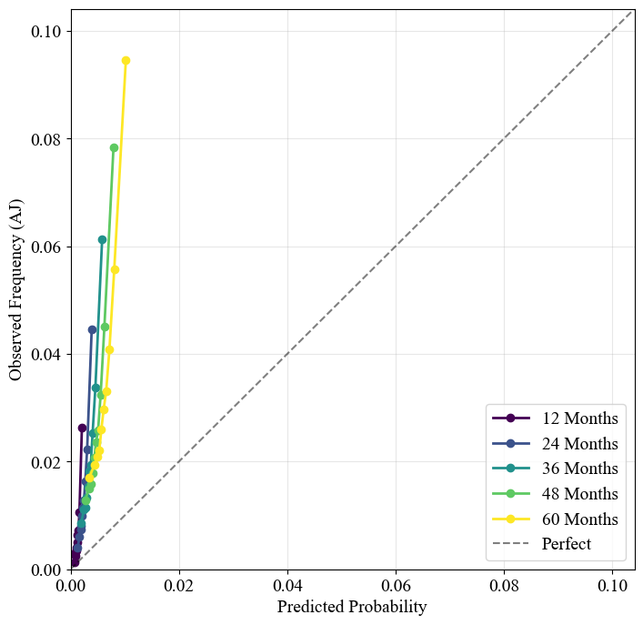

```
📈 Plotting Readmission (Risk ID: 2)...
```

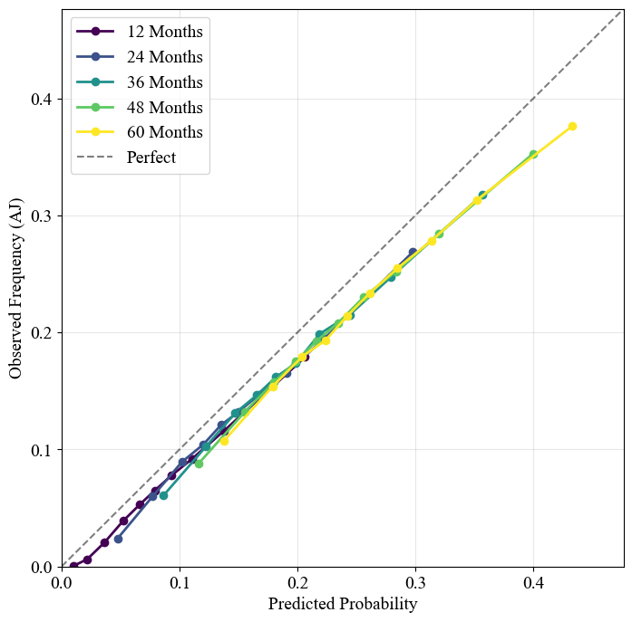

```python
#@title 📊 Step 5b: Calibration (Swapped Heads & Local Load)
import pandas as pd
import numpy as np
import matplotlib.pyplot as plt
import matplotlib.cm as cm
from lifelines import AalenJohansenFitter
import pickle
import os

# --- CONFIGURATION ---
# 1. Use the LOCAL path you just confirmed works
LOCAL_PKL_PATH = r"C:\Users\andre\temp_pred_file.pkl"
TARGET_TIMES = [12, 24, 36, 48, 60]
RISK_GROUPS = 10

timestamp = datetime.now().strftime("%Y%m%d_%H%M")
BASE_OUT = os.path.join(os.path.expanduser("~"), "dh5")
os.makedirs(BASE_OUT, exist_ok=True)

def get_calibration_data_swapped(raw_log, risk_id, time_point):
    all_pred = []

    # 🟢 CRITICAL FIX: SWAPPING THE HEADS
    # Based on your stats:
    # Head 0 (Avg 57%) -> Readmission (Risk 2)
    # Head 1 (Avg 25%) -> Death (Risk 1)

    if risk_id == 2: # Readmission
        network_index = 0  # Use Head 0
    elif risk_id == 1: # Death
        network_index = 1  # Use Head 1
    else:
        return None

    for entry in raw_log:
        cif_list = entry['cif_pred']
        dur_idx = entry['duration_index']
        y_time = entry['y_time_val']
        y_event = entry['y_event_val']

        # Find Time Index
        idx_t = np.searchsorted(dur_idx, time_point)
        if idx_t >= len(dur_idx): idx_t = len(dur_idx) - 1

        # Extract Prob
        prob_event = cif_list[network_index][idx_t, :]

        df_fold = pd.DataFrame({
            'prob': prob_event,
            'time': y_time,
            'event': y_event
        })
        all_pred.append(df_fold)

    if not all_pred: return None

    # Reset Index
    df_all = pd.concat(all_pred).reset_index(drop=True)

    try:
        df_all['decile'] = pd.qcut(df_all['prob'], RISK_GROUPS, labels=False, duplicates='drop')
    except:
        return None

    calibration_points = []
    ajf = AalenJohansenFitter(calculate_variance=False, jitter_level=0.001)

    for g in sorted(df_all['decile'].unique()):
        group = df_all[df_all['decile'] == g]
        mean_pred = group['prob'].mean()

        T = group['time']
        E = group['event']

        # Check if event exists
        if risk_id not in E.values:
            obs_freq = 0.0
        else:
            try:
                ajf.fit(T, E, event_of_interest=risk_id)
                if time_point > T.max():
                    obs_freq = ajf.predict(T.max()).item()
                else:
                    obs_freq = ajf.predict(time_point).item()
            except:
                obs_freq = np.nan

        calibration_points.append({'decile': g, 'mean_pred': mean_pred, 'obs_freq': obs_freq})

    return pd.DataFrame(calibration_points)

def plot_calibration_final(risk_name, risk_id, time_horizons):
    plt.figure(figsize=(8, 8))
    cmap = cm.get_cmap('viridis', len(time_horizons))
    max_val = 0

    # Load Data
    try:
        with open(LOCAL_PKL_PATH, 'rb') as f:
            raw_log = pickle.load(f)
    except Exception as e:
        print(f"❌ Could not load local file: {e}")
        return

    print(f"\n📈 Plotting {risk_name} (Risk ID: {risk_id})...")

    for i, t in enumerate(time_horizons):
        cal_df = get_calibration_data_swapped(raw_log, risk_id=risk_id, time_point=t)

        if cal_df is not None and not cal_df.empty:
            current_max = max(cal_df['mean_pred'].max(), cal_df['obs_freq'].max())
            if current_max > max_val: max_val = current_max

            plt.plot(cal_df['mean_pred'], cal_df['obs_freq'],
                     marker='o', linewidth=2, color=cmap(i), label=f"{t} Months")
        else:
            print(f"   ⚠️ No data for {t} months")

    # Plot diagonal
    limit = min(1.0, max_val * 1.1)
    plt.plot([0, 1], [0, 1], 'k--', alpha=0.5, label="Perfect")

    plt.xlim(0, limit)
    plt.ylim(0, limit)
    plt.xlabel("Predicted Probability")
    plt.ylabel("Observed Frequency (AJ)")
    #plt.title(f"Calibration: {risk_name}")
    plt.legend()
    plt.grid(True, alpha=0.3)
    plt.savefig(os.path.join(BASE_OUT, f"DH5_Calib_{risk_name}_{timestamp}.png"), dpi=300, bbox_inches="tight")
    plt.savefig(os.path.join(BASE_OUT, f"DH5_Calib_{risk_name}_{timestamp}.pdf"), bbox_inches="tight")
    plt.show()

print(os.path.join(BASE_OUT, f"DH5_Calib_{timestamp}.png"))

# --- EXECUTE ---
# We force the mapping:
# Death (1) -> uses Head 1
# Readm (2) -> uses Head 0
plot_calibration_final('Death', 1, TARGET_TIMES)
plot_calibration_final('Readmission', 2, TARGET_TIMES)
```